# Estimating a Bayes factor using bridge sampling

multilevel models

Bayes factor

A general method for estimating Bayes factors

true  
06-04-2021

# Bayes factor using bridge sampling

While the Savage-Dickey method is very useful for nested models, it is restricted to model comparisons between nested models, and it is not the most robust method.

We will look at an alternative method for obtaining Bayes factor, one that is both more reliable, and can be applied to model comparisons between non-nested models (as long as they are fit to the same data).

```r
library(tidyverse)
library(brms)
```

We will first simulate a dataset, using the function we defined in session 2.

```r
simulate_treatment <- function(a = 3.5,
                              b = -1,
                              sigma_a = 1,
                              sigma_b = 0.8,
                              rho = -0.7,
                              n_subjects = 10,
                              n_trials = 20,
                              sigma = 0.5) {

    # Ccombine the terms
    mu <- c(a, b)
    cov_ab <- sigma_a * sigma_b * rho
    SD  <- matrix(c(sigma_a^2, cov_ab,
                       cov_ab, sigma_b^2), ncol = 2)

   #  sigmas <- c(sigma_a, sigma_b)          # standard deviations
   #  rho <- matrix(c(1, rho,             # correlation matrix
   #                 rho, 1), nrow = 2)
   #
   # # now matrix multiply to get covariance matrix
   # SD <- diag(sigmas) %*% rho %*% diag(sigmas)

    varying_effects <-
        MASS::mvrnorm(n_subjects, mu, SD) |>
        # as_tibble(.name_repair = "unique") |>
        data.frame() |>
        purrr::set_names("a_j", "b_j")

    d_linpred <-
        varying_effects |>
        mutate(subject  = 1:n_subjects) |>
        expand(nesting(subject, a_j, b_j), post = c(0, 1)) |>
        mutate(mu = a_j + b_j * post,
               sigma = sigma) |>
        mutate(treatment = ifelse(post == 0, "pre", "post"),
               treatment = factor(treatment, levels = c("pre", "post")),
               subject = as_factor(subject))

    d <- d_linpred |>
        slice(rep(1:n(), each = n_trials)) |>
        mutate(response = rnorm(n = n(), mean = mu, sd = sigma))

   d
}
```

```r
plot_linpred <- function(d, violin = FALSE) {

  d_linpred <- d |>
  group_by(subject, treatment) |> distinct(mu, .keep_all = TRUE)

  p <- d_linpred |>
    ggplot(aes(x = treatment, y = mu))

  if (isTRUE(violin)) {
  p <- p +
      geom_violin(aes(x = treatment, y = response,
                          fill = treatment),
                  alpha = 0.5,
                  data = d) +
      geom_jitter(aes(x = treatment, y = response,
                          color = treatment),
                  width = 0.1, size = 2,
                  data = d)
  }

  p <- p +
    geom_line(aes(group = 1), color = "#8B9DAF", size = 1, linetype = 3) +
    geom_point(aes(fill = treatment),
               shape = 21,
               colour = "black",
               size = 4,
               stroke = 2) +
    scale_fill_brewer(type = "qual") +
    scale_color_brewer(type = "qual") +
    coord_cartesian(ylim = c(0, 8)) +
    ylab("Response") +
    theme(legend.position = "none",
          axis.ticks.x    = element_blank()) +
    facet_wrap(~ subject) +
  ggtitle("Linear predictor")

  p
}
```

We will create a hierarchical dataset, consisting of 30 subjects, measured at two time points (with 20 trials per time point).

```r
params <- tribble(~Parameter, ~`Default value`, ~Desccription,
                  "a", 2, "average pre-treatment effect (intercepts)",
                  "b", 0.5, "average difference between pre and post",
                  "sigma_a", 1, "std dev in intercepts",
                  "sigma_b", 2, "std dev in differences (slopes)",
                  "rho", -0.2, "correlation between intercepts and slopes",
                  "sigma", 0.5, "residual standard deviation")
params |>
    kableExtra::kbl() |>
    kableExtra::kable_paper("hover", full_width = T)
```

| Parameter | Default value | Desccription |
| --- | --- | --- |
| a | 2.0 | average pre-treatment effect (intercepts) |
| b | 0.5 | average difference between pre and post |
| sigma_a | 1.0 | std dev in intercepts |
| sigma_b | 2.0 | std dev in differences (slopes) |
| rho | -0.2 | correlation between intercepts and slopes |
| sigma | 0.5 | residual standard deviation |

```r
set.seed(867)
d <- simulate_treatment(n_subjects = 30,
                        a = 2, b = 0.5,
                        sigma_a = 1, sigma_b = 1.5,
                        rho = -0.2,
                        sigma = 0.5,
                        n_trials = 20)
```

We can plot 12 random subjects to get an idea of what the true means look like.

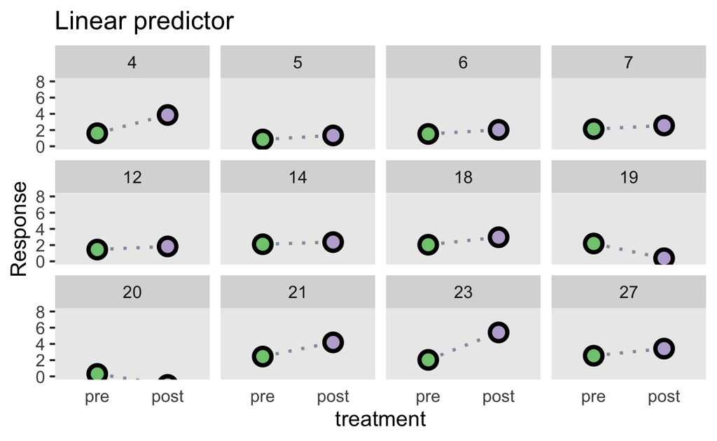

```r
random_subjects <- sample(levels(d$subject), 12)
d |>
  filter(subject %in% random_subjects) |> plot_linpred()
```

We will now attempt to estimate the parameter, using the model given by

$$\begin{align*}
\text{response}_i & \sim \operatorname{Normal}(\mu_i, \sigma) \\
\mu_i & = \alpha_{\text{subject}_i} + \beta_{\text{subject}_i} \text{treatment}_i \\
\begin{bmatrix} \alpha_\text{subject} \\ \beta_\text{treatment} \end{bmatrix} & \sim \text{MVNormal} \left (\begin{bmatrix} \alpha \\ \beta \end{bmatrix}, \mathbf{S} \right ) \\
\mathbf S & = \begin{bmatrix} \sigma_\alpha & 0 \\ 0 & \sigma_\beta \end{bmatrix} \mathbf R \begin{bmatrix} \sigma_\alpha & 0 \\ 0 & \sigma_\beta \end{bmatrix} \\
\end{align*}$$

We are assuming that our respone variable is conditionally normally distributed, with mean $\mu$ and standard deviation $\sigma$. We will predict the mean using a linear model, i.e. as a function of the treatments (pre and post).

The treatment variable is a factor with two levels, so we can use treamtent coding (the default in R) to give us an intercept representing the reference category, and an indicator variable representing the difference between the reference and non-reference categories.

```r
levels(d$treatment)
```

```
[1] "pre"  "post"
```

The first level of the variable will automatiaclly be used as the reference.

```r
contrasts(d$treatment)
```

```
     post
pre     0
post    1
```

In the output of the `contrasts()` function the column `post` shows the indicator variable that we will get, and the rows show the values it takes when the trial is from the pre or post condition, respectively.

Our formula will look like this: `response ~ 1 + treatment`. However, don’t simply want to estimate the avarage effect using a complete pooling model—we want to account for the fatc that every subject has their of mean response in the pre condition, and their own effect of the treatment, i.e. difference between pre and post treatment conditions.

We know (because we generated the data), that the average response in the pre condition is $\alpha = 2$ and the average difference between pre and post is $\beta = 0.5$, but if we look at the individual subjects, each one has their own effects $a_j$ and $b_j$. We want to simultaneously estimate the average effects, and the individual effects.

```r
d |>
  group_by(subject) |> slice_head(n = 1)
```

```
# A tibble: 30 x 8
# Groups:   subject [30]
   subject    a_j    b_j  post     mu sigma treatment response
   <fct>    <dbl>  <dbl> <dbl>  <dbl> <dbl> <fct>        <dbl>
 1 1       2.22    1.39      0 2.22     0.5 pre          1.96
 2 2       0.0683  1.11      0 0.0683   0.5 pre         -0.213
 3 3       3.46   -0.441     0 3.46     0.5 pre          3.12
 4 4       1.61    2.25      0 1.61     0.5 pre          2.21
 5 5       0.844   0.496     0 0.844    0.5 pre          1.46
 6 6       1.52    0.510     0 1.52     0.5 pre          1.23
 7 7       2.13    0.436     0 2.13     0.5 pre          2.02
 8 8       1.75    1.92      0 1.75     0.5 pre          0.653
 9 9       2.20   -2.16      0 2.20     0.5 pre          2.23
10 10      1.12    2.31      0 1.12     0.5 pre          1.01
# … with 20 more rows
```

This is what the lines

$$\mu_i = \alpha_{\text{subject}_i} + \beta_{\text{subject}_i} \text{treatment}_i$$

$$\begin{align*}
\begin{bmatrix} \alpha_\text{subject} \\ \beta_\text{treatment} \end{bmatrix} & \sim \text{MVNormal} \left (\begin{bmatrix} \alpha \\ \beta \end{bmatrix}, \mathbf{S} \right )
\end{align*}$$

are referring to. Each set of subject=specific $a_j$ and $b_j$ parameters is jointly drawn from a multivariate normal, with average effects $\alpha$ and $\beta$, and a covariance matrix $\Sigma$. In diagonal, $\Sigma$ contains the standard deviations, which tell us how much variation there is between subjects around the average effects. Lastly, we can estimate the correlation between $a_j$ and $b_j$; a negative correlation, for eaxmple, would imply that a large value in the pre condition would be associated with a smaller difference between pre and post.

The equations can be expressed as an R formula

```r
response ~ treatment + (treatment | subject)
```

```
response ~ treatment + (treatment | subject)
```

## Using maximum likelihood

If we were doing frequentist maximum likelook estimation, we would use this formula with the `lmer()` function from the `lme4` package.

```r
fit_lme4 <- lme4::lmer(response ~ treatment + (treatment | subject),
           data = d, REML = TRUE)
summary(fit_lme4)
```

```
Linear mixed model fit by REML ['lmerMod']
Formula: response ~ treatment + (treatment | subject)
   Data: d

REML criterion at convergence: 2042.2

Scaled residuals:
    Min      1Q  Median      3Q     Max
-3.7884 -0.6602 -0.0186  0.6604  2.7987

Random effects:
 Groups   Name          Variance Std.Dev. Corr
 subject  (Intercept)   0.7934   0.8908
          treatmentpost 2.3808   1.5430   -0.02
 Residual               0.2538   0.5038
Number of obs: 1200, groups:  subject, 30

Fixed effects:
              Estimate Std. Error t value
(Intercept)     1.9472     0.1639  11.879
treatmentpost   0.6861     0.2832   2.423

Correlation of Fixed Effects:
            (Intr)
treatmntpst -0.027
```

Can you identify all the parameters in the output, and find the corresponding true parameter values?

If you want p-values, you can use `lmerTest::lmer()`, because `lme4` doesn’t report p-values.

```r
fit_lmer <- lmerTest::lmer(response ~ treatment + (treatment | subject),
           data = d)
summary(fit_lmer)
```

```
Linear mixed model fit by REML. t-tests use Satterthwaite's method [
lmerModLmerTest]
Formula: response ~ treatment + (treatment | subject)
   Data: d

REML criterion at convergence: 2042.2

Scaled residuals:
    Min      1Q  Median      3Q     Max
-3.7884 -0.6602 -0.0186  0.6604  2.7987

Random effects:
 Groups   Name          Variance Std.Dev. Corr
 subject  (Intercept)   0.7934   0.8908
          treatmentpost 2.3808   1.5430   -0.02
 Residual               0.2538   0.5038
Number of obs: 1200, groups:  subject, 30

Fixed effects:
              Estimate Std. Error      df t value Pr(>|t|)
(Intercept)     1.9472     0.1639 29.0000  11.879 1.16e-12 ***
treatmentpost   0.6861     0.2832 28.9999   2.423   0.0219 *
---
Signif. codes:  0 '***' 0.001 '**' 0.01 '*' 0.05 '.' 0.1 ' ' 1

Correlation of Fixed Effects:
            (Intr)
treatmntpst -0.027
```

## Using Bayesian inference to obtain posteriors

Since we are Bayesian now, we would like to obtain posterior distributions for all the parameters. This means that we need priors. Let’s ask brms what priors we can set in this model, and what the defaults are.

```r
get_prior(response ~ treatment + (treatment | subject),
          data = d) |>
  as_tibble() |> select(1:4)
```

```
# A tibble: 10 x 4
   prior                    class     coef            group
   <chr>                    <chr>     <chr>           <chr>
 1 ""                       b         ""              ""
 2 ""                       b         "treatmentpost" ""
 3 "lkj(1)"                 cor       ""              ""
 4 ""                       cor       ""              "subject"
 5 "student_t(3, 2.2, 2.5)" Intercept ""              ""
 6 "student_t(3, 0, 2.5)"   sd        ""              ""
 7 ""                       sd        ""              "subject"
 8 ""                       sd        "Intercept"     "subject"
 9 ""                       sd        "treatmentpost" "subject"
10 "student_t(3, 0, 2.5)"   sigma     ""              ""
```

The defaults are acceptable, except for the flat prior of the average difference between pre and post, `treatmentpost`. This is not a good idea when estimating the parameter, but we could estimate the parameter from the data. When the goal is to obtain a Bayes factor, however, a flat prior makes it impossible to sample from the prior, and we need to set an informative prior.

We well therefore set a `normal(0, 1)` prior on the difference. This expresses our prior belief that the difference will lie between -2 and 2 with 95% certainty.

Do you think this is a good prior?

Additionallu, we will set an `LKJ(2)` prior on the correlation between intercepts and slopes, meaning that we expect the correlation to be centred at 0, and favouring smaller values, rather than being uniform between $[-1, 1]$.

```r
priors <- prior(normal(0, 1), class = b) +
  prior(lkj(2), class = cor)
```

Now we are ready to fit the model. We will now make sure that we save all the parameters using `save_pars = save_pars(all = TRUE),`, even those that are not save by default. This is necessary if we want to estimate the marginal likelhood using bridge sampling. The other thing is that now need to run the model for longer, i.e. we need many more iterations. A rule of thumb is a 10 fold increase in the number of iterations, but here we will settle for 10’000.

```r
fit_twosided <- brm(response ~ treatment + (treatment | subject),
                    prior = priors,
                    data = d,
                    save_pars = save_pars(all = TRUE),
                    iter = 1e4,
                    file = "models/fit_twosided",
                    file_refit = "on_change")
```

```r
summary(fit_twosided)
```

```
 Family: gaussian
  Links: mu = identity; sigma = identity
Formula: response ~ treatment + (treatment | subject)
   Data: d (Number of observations: 1200)
Samples: 4 chains, each with iter = 10000; warmup = 5000; thin = 1;
         total post-warmup samples = 20000

Group-Level Effects:
~subject (Number of levels: 30)
                             Estimate Est.Error l-95% CI u-95% CI
sd(Intercept)                    0.94      0.14     0.72     1.25
sd(treatmentpost)                1.62      0.23     1.25     2.14
cor(Intercept,treatmentpost)    -0.01      0.18    -0.36     0.33
                             Rhat Bulk_ESS Tail_ESS
sd(Intercept)                1.00     3676     5219
sd(treatmentpost)            1.00     3944     6364
cor(Intercept,treatmentpost) 1.00     3285     4596

Population-Level Effects:
              Estimate Est.Error l-95% CI u-95% CI Rhat Bulk_ESS
Intercept         1.95      0.17     1.61     2.29 1.00     2585
treatmentpost     0.64      0.28     0.08     1.19 1.00     2884
              Tail_ESS
Intercept         4662
treatmentpost     5648

Family Specific Parameters:
      Estimate Est.Error l-95% CI u-95% CI Rhat Bulk_ESS Tail_ESS
sigma     0.50      0.01     0.48     0.53 1.00    20542    13834

Samples were drawn using sampling(NUTS). For each parameter, Bulk_ESS
and Tail_ESS are effective sample size measures, and Rhat is the potential
scale reduction factor on split chains (at convergence, Rhat = 1).
```

Can you identify all the parameters?

```r
fixef(fit_twosided)
```

```
               Estimate Est.Error       Q2.5    Q97.5
Intercept     1.9468557 0.1738593 1.61017682 2.288157
treatmentpost 0.6412073 0.2825676 0.07713288 1.185885
```

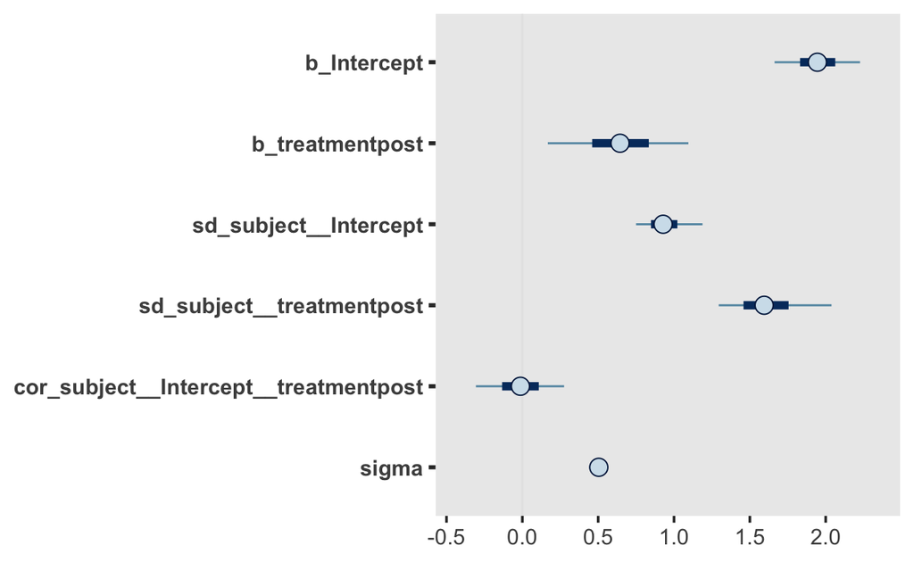

```r
mcmc_plot(fit_twosided)
```

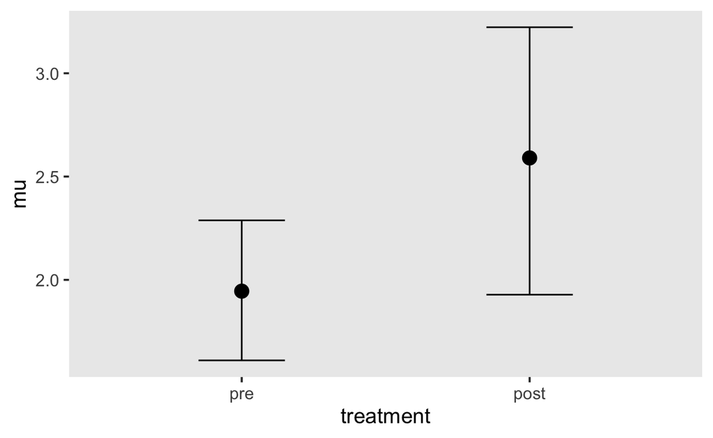

```r
conditional_effects(fit_twosided, dpar = "mu")
```

## Bayes factor

The posterior distribution of the parameter of interest gives us a 95% credible interval that is positive, but now we want to quantify evidence for the altervative hypothesis.

The next step is to specify an explicit null model. In this case, our null model is nested within the alternative, with the parameter representing the difference between treatments fixed to zero.

We can specify this model (with the varying treatment effects)

```r
fit_null_varying_effects <- brm(response ~ 1 + (treatment | subject),
                    prior = prior(lkj(2), class = cor),
                    data = d,
                    save_pars = save_pars(all = TRUE),
                    iter = 1e4,
                    file = "models/fit_null_varying",
                    file_refit = "on_change")
```

and the model without botj population-level and varying treatment effects.

```r
fit_null <- brm(response ~ 1 + (1 | subject),
                    data = d,
                    save_pars = save_pars(all = TRUE),
                    iter = 1e4,
                    file = "models/fit_null",
                    file_refit = "on_change")
```

We can now obtain the marginal log-likelihoods for these models using the `bridge_sampler()` function.

```r
margLogLik_twosided <- bridge_sampler(fit_twosided,
                                      silent = TRUE)

margLogLik_null_varying_effects <- bridge_sampler(fit_null_varying_effects,
                                                  silent = TRUE)

margLogLik_null <- bridge_sampler(fit_null,
                                    silent = TRUE)
```

Bayes factors can then be computed manually, or using the `bayes_factor()` function.

```r
exp(margLogLik_twosided$logml - margLogLik_null_varying_effects$logml)
```

```
[1] 3.373619
```

```r
BF_twosided_null <- bayes_factor(margLogLik_twosided, margLogLik_null_varying_effects)

BF_twosided_null
```

```
Estimated Bayes factor in favor of x1 over x2: 3.37362
```

You can also directly compute the Bayes factor without the intermediate step.

```r
bayes_factor(fit_twosided, fit_null_varying_effects)
```

[output not shown]

The Bayes factors obained via this method will vary, because they are estimated using a Monte Carlo sampling technique.

## Savage-Dickey

The same Bayes factor can be obtained via the Savage-Dickey density ration method:

```r
fit_twosided_SD <- brm(response ~ treatment + (treatment | subject),
                    prior = priors,
                    data = d,
                    sample_prior = TRUE,
                    iter = 2000,
                    file = "models/fit_twosided_SD",
                    file_refit = "on_change")
```

```r
BF_01 <- fit_twosided_SD |> hypothesis("treatmentpost = 0")
BF_10 <- 1/BF_01$hypothesis$Evid.Ratio
BF_10
```

```
[1] 3.05984
```

This results in a Bayes factor that is very similar to the one obtained via bridge sampling.

## Traditional methods

For comparison, let’s look at traditional ways of analyzing these data. The most common way to do this would be to perfom the data analysis at two levels. At the first level, we sumarise the data per subject and condition, aggregating over trials (Here we are ignoring our uncertainty in the subject means).

```r
d_sum <- d |>
  group_by(subject, treatment) |>
  summarise(response = mean(response))

d_sum
```

```
# A tibble: 60 x 3
# Groups:   subject [30]
   subject treatment response
   <fct>   <fct>        <dbl>
 1 1       pre          2.26
 2 1       post         3.55
 3 2       pre          0.198
 4 2       post         1.34
 5 3       pre          3.35
 6 3       post         3.12
 7 4       pre          1.73
 8 4       post         4.13
 9 5       pre          0.777
10 5       post         1.19
# … with 50 more rows
```

Subsequently, we perform a statistical test at the level 2, that at the group level, using the subject-specific means.

```r
t.test(response ~ treatment, data = d_sum, var.equal = FALSE)
```

```
    Welch Two Sample t-test

data:  response by treatment
t = -1.8925, df = 42.982, p-value = 0.06518
alternative hypothesis: true difference in means between group pre and group post is not equal to 0
95 percent confidence interval:
 -1.41724003  0.04504785
sample estimates:
 mean in group pre mean in group post
          1.947236           2.633333
```

```r
fit_ols <- lm(response ~ treatment, data = d_sum)
summary(fit_ols)
```

```
Call:
lm(formula = response ~ treatment, data = d_sum)

Residuals:
    Min      1Q  Median      3Q     Max
-3.6903 -0.7625  0.1156  0.7018  5.0725

Coefficients:
              Estimate Std. Error t value Pr(>|t|)
(Intercept)     1.9472     0.2564   7.596 2.92e-10 ***
treatmentpost   0.6861     0.3625   1.892   0.0634 .
---
Signif. codes:  0 '***' 0.001 '**' 0.01 '*' 0.05 '.' 0.1 ' ' 1

Residual standard error: 1.404 on 58 degrees of freedom
Multiple R-squared:  0.05816,   Adjusted R-squared:  0.04192
F-statistic: 3.581 on 1 and 58 DF,  p-value: 0.06342
```

```r
summary(fit_lmer)
```

```
Linear mixed model fit by REML. t-tests use Satterthwaite's method [
lmerModLmerTest]
Formula: response ~ treatment + (treatment | subject)
   Data: d

REML criterion at convergence: 2042.2

Scaled residuals:
    Min      1Q  Median      3Q     Max
-3.7884 -0.6602 -0.0186  0.6604  2.7987

Random effects:
 Groups   Name          Variance Std.Dev. Corr
 subject  (Intercept)   0.7934   0.8908
          treatmentpost 2.3808   1.5430   -0.02
 Residual               0.2538   0.5038
Number of obs: 1200, groups:  subject, 30

Fixed effects:
              Estimate Std. Error      df t value Pr(>|t|)
(Intercept)     1.9472     0.1639 29.0000  11.879 1.16e-12 ***
treatmentpost   0.6861     0.2832 28.9999   2.423   0.0219 *
---
Signif. codes:  0 '***' 0.001 '**' 0.01 '*' 0.05 '.' 0.1 ' ' 1

Correlation of Fixed Effects:
            (Intr)
treatmntpst -0.027
```

## Exercise

Follow all the steps shown above, but vary the parameters of the data generating function. You can set the true difference between treatment conditions to be zero, for example, or increase the standard deviation of the subjects’ difference parameters.

For example, setting the true difference to be zero (shown here for only 12 subjects—you should use more).

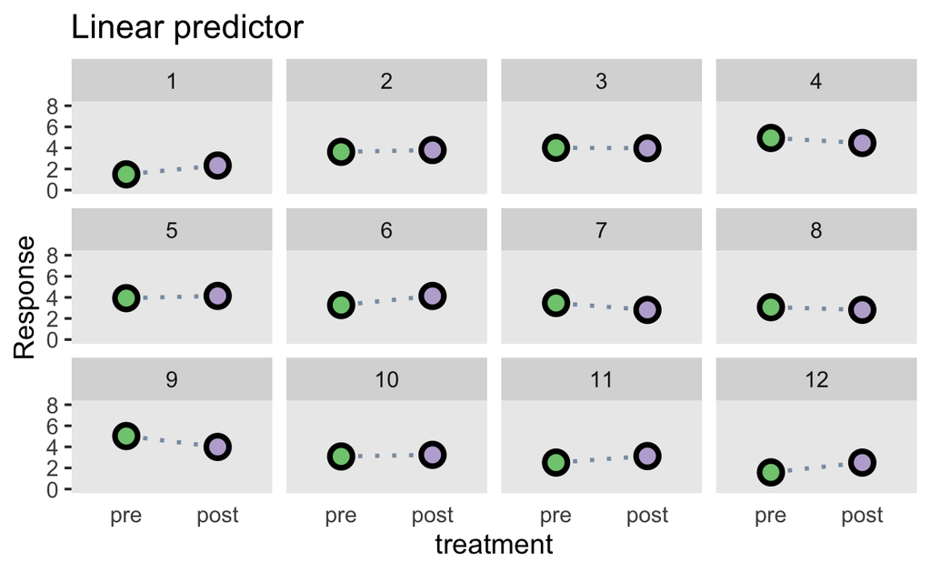

```r
dex1 <- simulate_treatment(b = 0, n_subjects = 12)
plot_linpred(dex1)
```

Setting the true difference to be zero and increasing the variability between subjects.

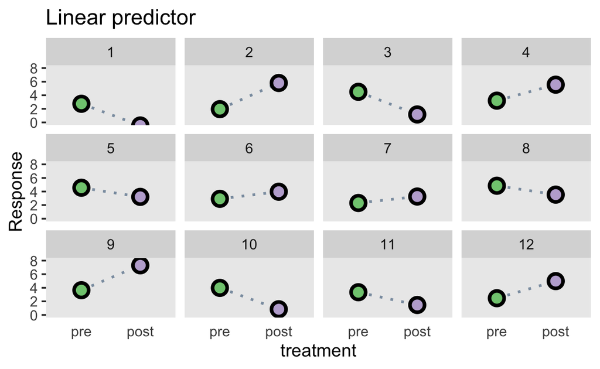

```r
dex2 <- simulate_treatment(b = 0, sigma_b = 2.5, n_subjects = 12)
plot_linpred(dex2)
```